# Westeros bis - emissions introduction and analysis

Copy of the scenario `westeros_bis_energymix1.ipynb` with the implementation of:

- emission impact of gas and coal
- emissions cap of 500 Mt of CO2.

### Pre-requisites

- You have the MESSAGEix framework installed and working
- You have run (`westeros_bis_baseline.ipynb`) scenario and solved it successfully
- You have run (`westeros_bis_energymix1.ipynb`) scenario

```python
import pandas as pd
import ixmp
import message_ix

from message_ix.util import make_df

%matplotlib inline
```

```python
mp = ixmp.Platform()
```

Recalling the model

```python
model = 'Westeros Electrified'
base = message_ix.Scenario(mp, model=model, scenario='energy mix1')
```

Creating emission scenario by cloning energy mix 1

```python
scen_em3 = base.clone(model, 'emissions3','adding emissions cap',
                  keep_solution=False)
scen_em3.check_out()
```

```python
year_df = scen_em3.vintage_and_active_years()
vintage_years, act_years = year_df['year_vtg'], year_df['year_act']
model_horizon = scen_em3.set('year')
country = 'Westeros'
```

Introducing emissions category, parameter, and value for coal and gas technology

```python
# first we introduce the emission of CO2 and the emission category GHG
scen_em3.add_set('emission', 'CO2')
scen_em3.add_cat('emission', 'GHG', 'CO2')

# we now add CO2 emissions to the coal powerplant
base_emission_factor = {
    'node_loc': country,
    'year_vtg': vintage_years,
    'year_act': act_years,
    'mode': 'standard',
    'unit': 'tCO2/kWa',
}

# adding new units to the model library (needed only once)
mp.add_unit('tCO2/kWa')
mp.add_unit('MtCO2')
```

```
INFO:root:unit `tCO2/kWa` is already defined in the platform instance
INFO:root:unit `MtCO2` is already defined in the platform instance
```

```python
emission_factor = { # values from https://doi.org/10.1016/B978-0-8155-2049-8.10007-5 converted to tCO2/kWa
    'coal_ppl': 7.07,
    'ngcc_ppl': 3.11,
    'wind_ppl': 0,
}

for tec, val in emission_factor.items():
    df = make_df(base_emission_factor, technology=tec, value=val, emission='CO2')
    scen_em3.add_par('emission_factor', df)
```

Introducing an upper bound

```python
scen_em3.add_par('bound_emission', [country, 'GHG', 'all', 'cumulative'],
             value=500., unit='MtCO2')
```

```python
scen_em3.par('emission_factor')
```

|  | node_loc | technology | year_vtg | year_act | mode | emission | value | unit |
| --- | --- | --- | --- | --- | --- | --- | --- | --- |
| 0 | Westeros | coal_ppl | 690 | 700 | standard | CO2 | 7.07 | tCO2/kWa |
| 1 | Westeros | coal_ppl | 690 | 710 | standard | CO2 | 7.07 | tCO2/kWa |
| 2 | Westeros | coal_ppl | 690 | 720 | standard | CO2 | 7.07 | tCO2/kWa |
| 3 | Westeros | coal_ppl | 700 | 700 | standard | CO2 | 7.07 | tCO2/kWa |
| 4 | Westeros | coal_ppl | 700 | 710 | standard | CO2 | 7.07 | tCO2/kWa |
| 5 | Westeros | coal_ppl | 700 | 720 | standard | CO2 | 7.07 | tCO2/kWa |
| 6 | Westeros | coal_ppl | 710 | 710 | standard | CO2 | 7.07 | tCO2/kWa |
| 7 | Westeros | coal_ppl | 710 | 720 | standard | CO2 | 7.07 | tCO2/kWa |
| 8 | Westeros | coal_ppl | 720 | 720 | standard | CO2 | 7.07 | tCO2/kWa |
| 9 | Westeros | ngcc_ppl | 690 | 700 | standard | CO2 | 3.11 | tCO2/kWa |
| 10 | Westeros | ngcc_ppl | 690 | 710 | standard | CO2 | 3.11 | tCO2/kWa |
| 11 | Westeros | ngcc_ppl | 690 | 720 | standard | CO2 | 3.11 | tCO2/kWa |
| 12 | Westeros | ngcc_ppl | 700 | 700 | standard | CO2 | 3.11 | tCO2/kWa |
| 13 | Westeros | ngcc_ppl | 700 | 710 | standard | CO2 | 3.11 | tCO2/kWa |
| 14 | Westeros | ngcc_ppl | 700 | 720 | standard | CO2 | 3.11 | tCO2/kWa |
| 15 | Westeros | ngcc_ppl | 710 | 710 | standard | CO2 | 3.11 | tCO2/kWa |
| 16 | Westeros | ngcc_ppl | 710 | 720 | standard | CO2 | 3.11 | tCO2/kWa |
| 17 | Westeros | ngcc_ppl | 720 | 720 | standard | CO2 | 3.11 | tCO2/kWa |
| 18 | Westeros | wind_ppl | 690 | 700 | standard | CO2 | 0.00 | tCO2/kWa |
| 19 | Westeros | wind_ppl | 690 | 710 | standard | CO2 | 0.00 | tCO2/kWa |
| 20 | Westeros | wind_ppl | 690 | 720 | standard | CO2 | 0.00 | tCO2/kWa |
| 21 | Westeros | wind_ppl | 700 | 700 | standard | CO2 | 0.00 | tCO2/kWa |
| 22 | Westeros | wind_ppl | 700 | 710 | standard | CO2 | 0.00 | tCO2/kWa |
| 23 | Westeros | wind_ppl | 700 | 720 | standard | CO2 | 0.00 | tCO2/kWa |
| 24 | Westeros | wind_ppl | 710 | 710 | standard | CO2 | 0.00 | tCO2/kWa |
| 25 | Westeros | wind_ppl | 710 | 720 | standard | CO2 | 0.00 | tCO2/kWa |
| 26 | Westeros | wind_ppl | 720 | 720 | standard | CO2 | 0.00 | tCO2/kWa |

Solving the model

```python
scen_em3.commit(comment='introducing emissions and setting an upper bound')
scen_em3.set_as_default()
```

```python
scen_em3.solve()
```

```python
scen_em3.var('OBJ')['lvl']
```

```
455626.65625
```

Plotting the results

```python
from message_ix.reporting import Reporter
from message_ix.util.tutorial import prepare_plots

rep = Reporter.from_scenario(scen_em3)
prepare_plots(rep)
```

Activity

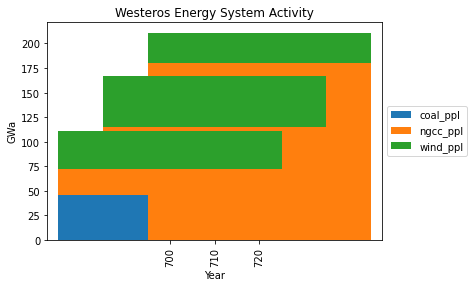

```python
rep.set_filters(t=["coal_ppl", "wind_ppl","ngcc_ppl"])
rep.get("plot activity")
```

Capacity

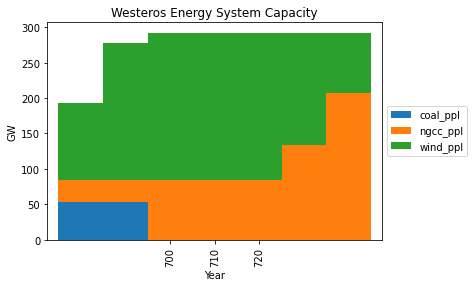

```python
rep.get("plot capacity")
```

Electricy price

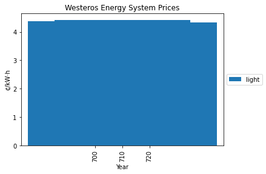

```python
rep.set_filters(t=None, c=["light"])
rep.get("plot prices")
```

Take a more detailed look into carbon emissions by decade, and equivalent emission prices

```python
emissions = scen_em3.var('EMISS', {'node': 'Westeros'})
emissions
```

|  | node | emission | type_tec | year | lvl | mrg |
| --- | --- | --- | --- | --- | --- | --- |
| 0 | Westeros | CO2 | all | 700 | 402.632677 | 0.0 |
| 1 | Westeros | CO2 | all | 710 | 535.693108 | 0.0 |
| 2 | Westeros | CO2 | all | 720 | 561.674215 | 0.0 |

```python
emission_prices = scen_em3.var('PRICE_EMISSION')
emission_prices
```

|  | node | type_emission | type_tec | year | lvl | mrg |
| --- | --- | --- | --- | --- | --- | --- |
| 0 | Westeros | GHG | all | 700 | 14.471761 | 0.0 |
| 1 | Westeros | GHG | all | 710 | 23.572973 | 0.0 |
| 2 | Westeros | GHG | all | 720 | 38.397889 | 0.0 |

# Comments on the results

Therefore, with the method of the emission bound, the sweet spot is achieved in the previous scenario `westeros_bis_emissions_cap2.ipynb` with a cap of 600 MtCO2 and a carbon price of about (10, 16, 27) USD/tCO2 in the three decades.

In the next scenario it will be explored a different method of limiting emission, that is a constant carbon tax, and the existence of a 'sweet spot carbon price' will be explored.

Close connection to the database

```python
mp.close_db()
```